# R Notebook

```r
# general visualisation
library(ggplot2) # visualisation
library(scales) # visualisation
library(patchwork) # visualisation
library(RColorBrewer) # visualisation
library(corrplot) # visualisation
library(ggthemes) # visualisation
library(ggrepel) # visualisation
# general data manipulation
library(dplyr) # data manipulation
library(readr) # input/output
library(vroom) # input/output
library(skimr) # overview
library(tibble) # data wrangling
library(tidyr) # data wrangling
library(stringr) # string manipulation
library(forcats) # factor manipulation
# specific visualisation
library(alluvial) # visualisation
library(ggrepel) # visualisation
library(ggforce) # visualisation
library(ggridges) # visualisation
library(gganimate) # animations
library(GGally) # visualisation
library(ggExtra) # visualisation
library(viridis) # visualisation
library(gridExtra)
library(usmap) # geo
library(PerformanceAnalytics)
library(pheatmap)
library(dichromat)
# specific data manipulation
library(lazyeval) # data wrangling
library(broom) # data wrangling
library(purrr) # data wrangling
library(reshape2) # data wrangling
library(rlang) # encoding
library(kableExtra) # display
library(tm)
# networks
library(igraph)
library(GGally)
library(ergm)
library(intergraph)
```

# Data Loading

```r
### 1.1. General dataframes
setwd("C:/Kaggle/Data/March_Madness_Analytics_2020")
```

```
The working directory was changed to C:/Kaggle/Data/March_Madness_Analytics_2020 inside a notebook chunk. The working directory will be reset when the chunk is finished running. Use the knitr root.dir option in the setup chunk to change the working directory for notebook chunks.
```

```r
# Load Players data
df_Players <- read.csv('MPlayByPlay_Stage2/MPlayers.csv')
# Load Team data
df_Teams <- read.csv('MDataFiles_Stage2/MTeams.csv')
df_TeamCoaches <- read.csv('MDataFiles_Stage2/MTeamCoaches.csv')
df_TeamConferences <- read.csv('MDataFiles_Stage2/MTeamConferences.csv')
df_TeamSpellings <- read.csv('MDataFiles_Stage2/MTeamSpellings.csv')
# Load Cities data
df_Cities <- read.csv('MDataFiles_Stage2/Cities.csv')
df_GameCities <- read.csv('MDataFiles_Stage2/MGameCities.csv')
# Public Rankings
df_MasseyOrdinals <- read.csv('MDataFiles_Stage2/MMasseyOrdinals.csv')
# Conferences
df_Conferences <- read.csv('MDataFiles_Stage2/Conferences.csv')
df_ConferencesTourneyGames <- read.csv('MDataFiles_Stage2/MConferenceTourneyGames.csv')
# Tourney results
df_TourneyCompactResults <- read.csv('MDataFiles_Stage2/MNCAATourneyCompactResults.csv')
df_TourneyDetailedResults <- read.csv('MDataFiles_Stage2/MNCAATourneyDetailedResults.csv')
df_TourneySeedRoundSlots <- read.csv('MDataFiles_Stage2/MNCAATourneySeedRoundSlots.csv')
df_TourneySeeds <- read.csv('MDataFiles_Stage2/MNCAATourneySeeds.csv')
df_TourneySlots <- read.csv('MDataFiles_Stage2/MNCAATourneySlots.csv')
# Secondary results
df_SecondaryTourneyCompactResults <- read.csv('MDataFiles_Stage2/MSecondaryTourneyCompactResults.csv')
df_SecondaryTourneyTeams <- read.csv('MDataFiles_Stage2/MSecondaryTourneyTeams.csv')
# Regular Season results
df_RegularSeasonCompactResults <- read.csv('MDataFiles_Stage2/MRegularSeasonCompactResults.csv')
df_RegularSeasonDetailedResults <- read.csv('MDataFiles_Stage2/MRegularSeasonDetailedResults.csv')
# Seasons
df_Seasons <- read.csv('MDataFiles_Stage2/MSeasons.csv')
```

```r
play_by_play <- data.frame()
# loop through each seasons PlayByPlay folders and read in in the play by play files
setwd("C:/Kaggle/Data/March_Madness_Analytics_2020/MPlayByPlay_Stage2")
```

```
The working directory was changed to C:/Kaggle/Data/March_Madness_Analytics_2020/MPlayByPlay_Stage2 inside a notebook chunk. The working directory will be reset when the chunk is finished running. Use the knitr root.dir option in the setup chunk to change the working directory for notebook chunks.
```

```r
#for(each in list.files()[str_detect(list.files(), "MEvents")]) {
#
#  df <- read_csv(paste0(each))
#
#  # Grouped shooting variables ----------------------------------------------
#  # there are some shooting variables that can probably be condensed - tip ins and dunks
##  paint_attempts_made <- c("made2_dunk", "made2_lay", "made2_tip")
#  paint_attempts_missed <- c("miss2_dunk", "miss2_lay", "miss2_tip")
#  paint_attempts <- c(paint_attempts_made, paint_attempts_missed)
#  # create variables for field goals made, and also field goals attempted (which includes the sum of FGs made and FGs missed)
#  FGM <- c("made2_dunk", "made2_jump", "made2_lay",  "made2_tip",  "made3_jump")
#  FGA <- c(FGM, "miss2_dunk", "miss2_jump" ,"miss2_lay",  "miss2_tip",  "miss3_jump")
#  # variable for three-pointers
#  ThreePointer <- c("made3_jump", "miss3_jump")
#  #  Two point jumper
#  TwoPointJump <- c("miss2_jump", "made2_jump")
#  # Free Throws
#  FT <- c("miss1_free", "made1_free")
#  # all shots
#  AllShots <- c(FGA, FT)
#
#
#  # Feature Engineering -----------------------------------------------------
#  # paste the two even variables together for FGs as this is the format for last years comp data
#  df <- df %>%
#    mutate_if(is.factor, as.character) %>%
#    mutate(EventType = ifelse(str_detect(EventType, "miss") | str_detect(EventType, "made") | str_detect(EventType, "reb"), paste0(EventType, "_", EventSubType), EventType))
#
#  # change the unknown for 3s to "jump" and for FTs "free"
#  df <- df %>%
#    mutate(EventType = ifelse(str_detect(EventType, "3"), str_replace(EventType, "_unk", "_jump"), EventType),
#           EventType = ifelse(str_detect(EventType, "1"), str_replace(EventType, "_unk", "_free"), EventType))
#
#
#  df <- df %>%
#    # create a variable in the df for whether the attempts was made or missed
#    mutate(shot_outcome = ifelse(grepl("made", EventType), "Made", ifelse(grepl("miss", EventType), "Missed", NA))) %>%
#    # identify if the action was a field goal, then group it into the attempt types set earlier
#    mutate(FGVariable = ifelse(EventType %in% FGA, "Yes", "No"),
#           AttemptType = ifelse(EventType %in% paint_attempts, "PaintPoints",
#                                ifelse(EventType %in% ThreePointer, "ThreePointJumper",
#                                       ifelse(EventType %in% TwoPointJump, "TwoPointJumper",
#                                              ifelse(EventType %in% FT, "FreeThrow", "NoAttempt")))))
#
#
#  # Rework DF so only shots are included and whatever lead to the shot --------
#  df <- df %>%
#    mutate(GameID = paste(Season, DayNum, WTeamID, LTeamID, sep = "_")) %>%
#    group_by(GameID, ElapsedSeconds) %>%
#    mutate(EventType2 = lead(EventType),
#           EventPlayerID2 = lead(EventPlayerID)) %>% ungroup()
#
#
#  df <- df %>%
#    mutate(FGVariableAny = ifelse(EventType %in% FGA | EventType2 %in% FGA, "Yes", "No")) %>%
#    filter(FGVariableAny == "Yes")
#
#
#  # create a variable for if the shot was made, but then the second event was also a made shot
#  df <- df %>%
#    mutate(Alert = ifelse(EventType %in% FGM & EventType2 %in% FGM, "Alert", "OK")) %>%
#    # only keep "OK" observations
#    filter(Alert == "OK")
#
#
#  # replace NAs with somerhing
#  df$EventType2[is.na(df$EventType2)] <- "no_second_event"
#
#
#  # create a variable for if there was an assist on the FGM:
#  df <- df %>%
#    mutate(AssistedFGM = ifelse(EventType %in% FGM & EventType2 == "assist", "Assisted",
#                                ifelse(EventType %in% FGM & EventType2 != "assist", "Solo",
#                                       ifelse(EventType %in% FGM & EventType2 == "no_second_event", "Solo", "None"))))
#
#  # # because the FGA culd be either in `EventType` (more likely) or `EventType2` (less likely), need
#  # # one variable to indicate the shot type
#  # df <- df %>% \
#  #   mutate(fg_type = ifelse(EventType %in% FGA, EventType, ifelse(EventType2 %in% FGA, EventType2, "Unknown")))
#
#  # create final output
#  df <- df %>% ungroup()
#  play_by_play <- bind_rows(play_by_play, df)
#  print(each)
#
#  rm(df); gc()
#}
#
#saveRDS(play_by_play, "play_by_play2015_19.rds")
# Load preprocessed final play-by-play data
#setwd("C:/Users/Artem/Google Drive/KAGGLE/March_Madness_Analytics_2020/MPlayByPlay_Stage2")
play_by_play <- readRDS("play_by_play2015_19.rds")
# Select Season
play_by_play <- play_by_play[play_by_play$Season == 2019,]
```

# Introduction

Every team sport is a not only about the individual statistics of team or a player but more about overall dynamics and interactions between them. But how can we account for such interactions in the meaningfull and scientific way? In this notebook we gonna use Network approach to the analysis of the sport data to answer the set of different question regarding players interaction on the micro-level and overall team perfomance during the season on the macro-level. In particular we are intrested to find the answers to following questions:

1. How we can operationalize importance of a player for the team and what are the players which are most important?
2. What are the teams what rely mostly on the one “Talisman” player and what are the teams that have more equal squad?
3. How can we define competitiveness during the regular season games and what are the conferencess with more competitiveness?
4. What team statistics account for the winning strategy and how diffence in such statistics between two teams influence the result of the match?

# Part 1. Network of Players

```r
################ 1. CREATE NETWORKS OF ASSISTS
# Select only plays with assists
play_by_play <- subset(play_by_play, EventType2 == "assist")
# Create list with Team IDs
team_ids <- unique(play_by_play$EventTeamID)
# Remove missing team ids
if(0 %in% team_ids){
  team_ids <- team_ids[-which(team_ids == 0)]
}
createAssistsGraph <- function(team_id, play_by_play=play_by_play){
  # Select only one team
  play_by_play <- play_by_play[play_by_play$EventTeamID == team_id,]

  # Create edgeslist for one team, First column - assisted, Second column -  made a shot.
  play_by_play$EventPlayerID2 <- as.character(play_by_play$EventPlayerID2)
  play_by_play$EventPlayerID <- as.character(play_by_play$EventPlayerID)
  edgelist <- play_by_play[,c("EventPlayerID2", "EventPlayerID")]

  ### Remove duplicated edges and add weights instead
  # Create pair from each nodes in the edge
  edgelist$pair <- paste(edgelist$EventPlayerID2, edgelist$EventPlayerID, sep = "_")
  # Create dataframe with pairs and corresponding weights
  pair_weights <- data.frame(table(edgelist$pair))
  colnames(pair_weights) <- c("pair", 'weight')
  pair_weights$pair <- as.character(pair_weights$pair)
  # Remove duplicated edges
  edgelist <- edgelist[!duplicated(edgelist$pair),]
  # Add weights to the edgelist
  edgelist <- edgelist %>% left_join(pair_weights, 'pair')
  edgelist$pair <- NULL

  # Remove missing player ids
  edgelist <- edgelist[!is.na(edgelist$EventPlayerID2),]
  edgelist <- edgelist[!is.na(edgelist$EventPlayerID),]

  # Remove 0 player ids
  edgelist <- edgelist[edgelist$EventPlayerID2 != 0,]
  edgelist <- edgelist[edgelist$EventPlayerID != 0,]

  # Create graph from edgelist
  G <- igraph::graph_from_edgelist(as.matrix(edgelist[c("EventPlayerID2", "EventPlayerID")]))
  # Add weights
  E(G)$weight <- edgelist$weight

  # Remove self loops
  G <- igraph::simplify(G)

  return(G)
}
# Create assists graphs for all teams
assist_graphs_list <- list()
for(i in 1:length(team_ids)){
  assist_graphs_list[[i]] <- createAssistsGraph(team_ids[i], play_by_play)
}
```

## 1.1. Network statistics for the players.

```r
calculatePlayerNetworkStatistics <- function(g){

  # 1. Players ids
  player_ids <- names(V(g))

  # 2. Betweenness
  betweenness_vec <- betweenness(g, normalized=T)

  # 3. Page Rank
  pagerank_vec <- page.rank(g)$vector
  pagerank_vec <- pagerank_vec/sum(pagerank_vec)


  return(list(PlayerID=player_ids,
              betweenness=betweenness_vec,
              pagerank=pagerank_vec))
}
df_PlayersNetworkStats <- lapply(assist_graphs_list, calculatePlayerNetworkStatistics)
df_PlayersNetworkStats <- do.call(rbind.data.frame, df_PlayersNetworkStats)
df_PlayersNetworkStats <- df_PlayersNetworkStats %>% mutate(PlayerID=as.character(PlayerID))
# Add full names of players to df with network stats
df_Players <- df_Players %>% mutate(FullName=paste(FirstName, LastName),
                                    PlayerID=as.character(PlayerID))
df_PlayersNetworkStats <- df_PlayersNetworkStats %>%
  left_join(df_Players %>% select(PlayerID, FullName))
```

So lets look who is the TOP-15 players by PageRank centrality in their teams.

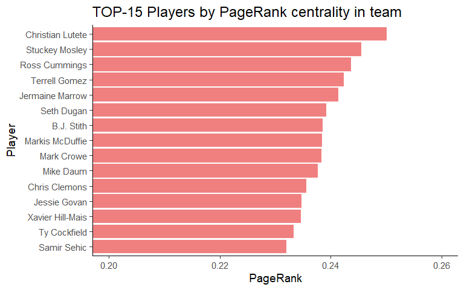

```r
# TOP 15 Players with highest PageRank
df_PlayersNetworkStats %>% arrange(-pagerank) %>% head(15) %>%
  ggplot(aes(reorder(FullName, pagerank), pagerank)) +
  geom_col(fill="lightcoral") + scale_y_continuous(limits = c(0.2,0.26), oob=rescale_none) +
  coord_flip() + theme_classic(base_size = 14) + ggtitle("TOP-15 Players by PageRank centrality in team") +
  labs(y="PageRank", x = "Player") +
  theme(plot.title = element_text(size = 18))
```

As we can see Christian Lutete has a highest PageRank amoungst others.

Lets look at the most “betweenness” players for the team.

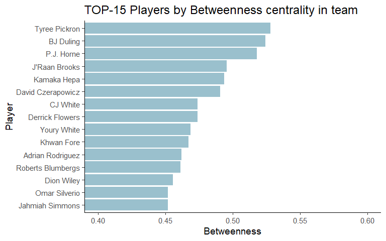

```r
# TOP 15 Players with highest Betweenness
df_PlayersNetworkStats %>% arrange(-betweenness) %>% head(15) %>%
  ggplot(aes(reorder(FullName, betweenness), betweenness)) +
  geom_col(fill="lightblue3") + scale_y_continuous(limits = c(0.4,0.6), oob=rescale_none) +
  coord_flip() + theme_classic(base_size = 14) + ggtitle("TOP-15 Players by Betweenness centrality in team") +
  labs(y="Betweenness", x = "Player") +
  theme(plot.title = element_text(size = 18))
```

In this case Tyree Pickron, BJ Duling and P.J. Horne are playing the role of great “connectors” for the goal moments.

## 1.2. Network statistics (centralization) for the teams.

Of course we cannot compare these players directly to each since this measure mostly reflects the inside team impacts the player has. But what can we do to compare the teams directly to each other? In this case it might be usefull to calculate so called “centralization” of a whole network. High centralization will mean that the team is rely mostly on few number of players, while we low centralization will indicate the cituation where responsibilities are distributed equaly amongst the team members. So lets look at the teams with highest and lowest PageRank centralization to get a better understanding of what it really means.

### Example of teams with High and Low PageRank centralization.

```r
# 1. Example of the network with Biggest PageRank centralization
# Create the graph
G <- assist_graphs_list[[which.max(df_TeamsNetworkStats$pagerank_centralization)]]
G_name <- as.character(df_TeamsNetworkStats[which.max(df_TeamsNetworkStats$pagerank_centralization),]$TeamName)
# Set vertex size end edge width for plotting
vertex_size <- page.rank(G)$vector * 100
vertex_size <- ifelse(vertex_size <= 5, 5, vertex_size)
edge_width <- E(G)$weight*0.3
# Add player names
vertex_ids <- data.frame(PlayerID=names(V(G)))
vertex_fullnames <- (vertex_ids %>% left_join(df_Players %>% select(PlayerID, FullName)))$FullName
```

```
Column `PlayerID` joining factor and character vector, coercing into character vector
```

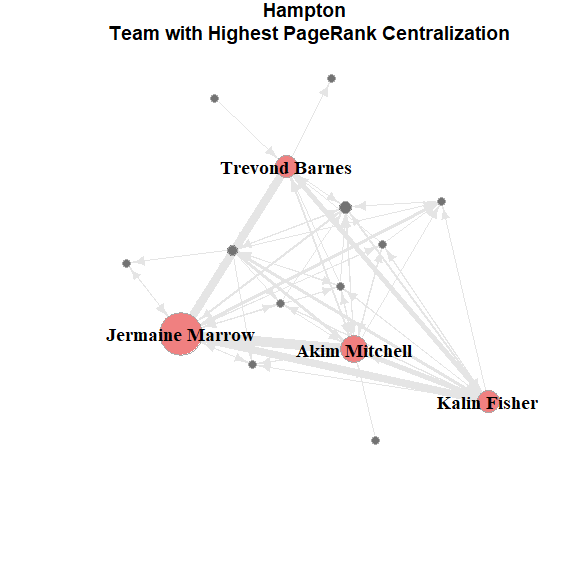

```r
G <- set_vertex_attr(G, "fullname", value=vertex_fullnames)
# Plot the graph
plot.igraph(G, edge.arrow.size=0.7, layout=layout.kamada.kawai, edge.width=edge_width,
            vertex.size=vertex_size, vertex.frame.color='darkgrey', edge.color='gray90',
            vertex.label=ifelse(vertex_size>10, vertex.attributes(G)$fullname, NA),
            vertex.label.color='black', vertex.label.font=2, vertex.label.cex=1.2,
            vertex.color=ifelse(vertex_size>10, "lightcoral", "gray45"),
            main=paste(G_name, '\n Team with Highest PageRank Centralization'))
```

```r
# 2. Example of the network with Lowest PageRank centralization
# Create the graph
G <- assist_graphs_list[[which.min(df_TeamsNetworkStats$pagerank_centralization)]]
G_name <- as.character(df_TeamsNetworkStats[which.min(df_TeamsNetworkStats$pagerank_centralization),]$TeamName)
# Set vertex size end edge width for plotting
vertex_size <- page.rank(G)$vector * 100
vertex_size <- ifelse(vertex_size <= 5, 5, vertex_size)
edge_width <- E(G)$weight*0.3
# Add player names
vertex_ids <- data.frame(PlayerID=names(V(G)))
vertex_fullnames <- (vertex_ids %>% left_join(df_Players %>% select(PlayerID, FullName)))$FullName
```

```
Column `PlayerID` joining factor and character vector, coercing into character vector
```

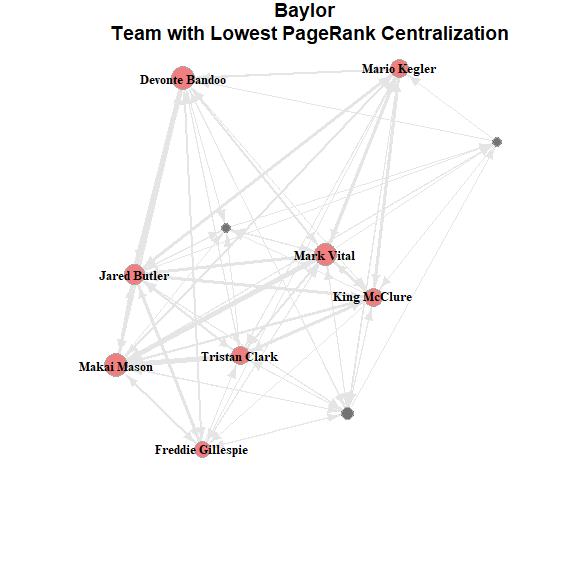

```r
G <- set_vertex_attr(G, "fullname", value=vertex_fullnames)
# Plot the graph
plot.igraph(G, edge.arrow.size=0.7, layout=layout.kamada.kawai, edge.width=edge_width,
            vertex.size=vertex_size, vertex.frame.color='darkgrey', edge.color='gray90',
            vertex.label=ifelse(vertex_size>7, vertex.attributes(G)$fullname, NA),
            vertex.label.color='black', vertex.label.font=2, vertex.label.cex=0.8,
            vertex.color=ifelse(vertex_size>7, "lightcoral", "gray45"),
            main=paste(G_name, '\n Team with Lowest PageRank Centralization'))
```

There is huge disbalance in Hampton team towards 4 players, while in Baylor the PageRank distributed evenly across the members.

Lets look at the same plots, but now with examples of betweenness centralization.

### Example of teams with High and Low Betweenness centralization.

```r
# 3. Example of the network with Highest Betweenness centralization
# Create the graph
G <- assist_graphs_list[[which.max(df_TeamsNetworkStats$betweenness_centralization)]]
G_name <- as.character(df_TeamsNetworkStats[which.max(df_TeamsNetworkStats$betweenness_centralization),]$TeamName)
# Set vertex size end edge width for plotting
vertex_size <- as.numeric(betweenness(G, normalized=T))*50
vertex_size <- ifelse(vertex_size <= 5, 5, vertex_size)
edge_width <- E(G)$weight*0.3
# Add player names
vertex_ids <- data.frame(PlayerID=names(V(G)))
vertex_fullnames <- (vertex_ids %>% left_join(df_Players %>% select(PlayerID, FullName)))$FullName
```

```
Column `PlayerID` joining factor and character vector, coercing into character vector
```

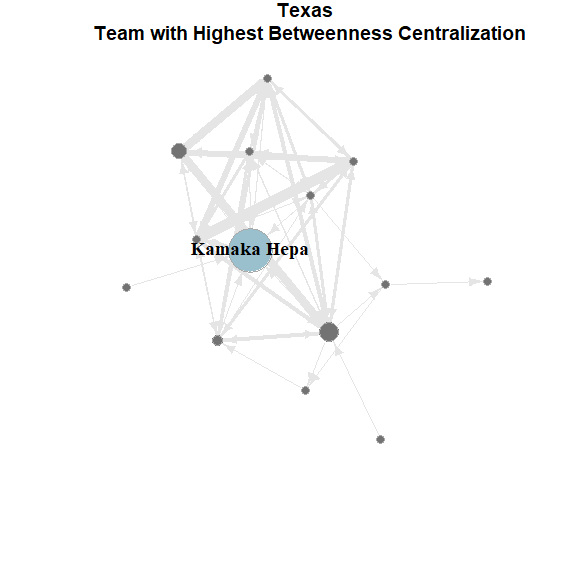

```r
G <- set_vertex_attr(G, "fullname", value=vertex_fullnames)
# Plot the graph
plot.igraph(G, edge.arrow.size=0.7, layout=layout.kamada.kawai, edge.width=edge_width,
            vertex.size=vertex_size, vertex.frame.color='darkgrey', edge.color='gray90',
            vertex.label=ifelse(vertex_size>20, vertex.attributes(G)$fullname, NA),
            vertex.label.color='black', vertex.label.font=2, vertex.label.cex=1.2,
            vertex.color=ifelse(vertex_size>20, "lightblue3", "gray45"),
            main=paste(G_name, '\n Team with Highest Betweenness Centralization'))
```

```r
# 4. Example of the network with Lowest Betweenness centralization
# Create the graph
G <- assist_graphs_list[[which.min(df_TeamsNetworkStats$betweenness_centralization)]]
G_name <- as.character(df_TeamsNetworkStats[which.min(df_TeamsNetworkStats$betweenness_centralization),]$TeamName)
# Set vertex size end edge width for plotting
vertex_size <- as.numeric(betweenness(G, normalized=T))*50
vertex_size <- ifelse(vertex_size <= 5, 5, vertex_size)
edge_width <- E(G)$weight*0.15
# Add player names
vertex_ids <- data.frame(PlayerID=names(V(G)))
vertex_fullnames <- (vertex_ids %>% left_join(df_Players %>% select(PlayerID, FullName)))$FullName
```

```
Column `PlayerID` joining factor and character vector, coercing into character vector
```

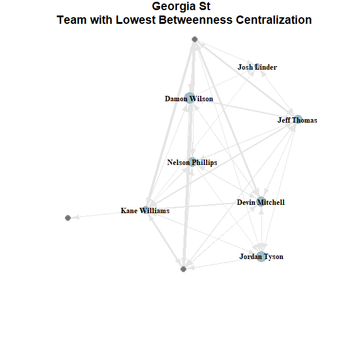

```r
G <- set_vertex_attr(G, "fullname", value=vertex_fullnames)
# Plot the graph
plot.igraph(G, edge.arrow.size=0.7, layout=layout.kamada.kawai, edge.width=edge_width,
            vertex.size=vertex_size, vertex.frame.color='darkgrey', edge.color='gray90',
            vertex.label=ifelse(vertex_size>5, vertex.attributes(G)$fullname, NA),
            vertex.label.color='black', vertex.label.font=2, vertex.label.cex=0.8,
            vertex.color=ifelse(vertex_size>5, "lightblue3", "gray45"),
            main=paste(G_name, '\n Team with Lowest Betweenness Centralization'))
```

There is huge Betweenness centralization in the Texas baseketball team, the overall connectivity between players will drop dramatically if the enemy team is gonna be able to efficiently netralize just one player - Kamaka Hepa

### Linear regression with Centralization metrics as IV and Median Rank during the season as DV.

```r
# TODO: Number of wins instead of median rank?
summary(lm(median_rank ~ mean_transitivity + betweenness_centralization +
             closeness_centralization + pagerank_centralization,
       df_TeamsNetworkStats))
```

```
Call:
lm(formula = median_rank ~ mean_transitivity + betweenness_centralization +
    closeness_centralization + pagerank_centralization, data = df_TeamsNetworkStats)

Residuals:
    Min      1Q  Median      3Q     Max
-218.06  -82.61   -2.23   82.28  205.02

Coefficients:
                           Estimate Std. Error t value Pr(>|t|)
(Intercept)                 -14.161     68.816  -0.206 0.837084
mean_transitivity           144.741     60.364   2.398 0.017020 *
betweenness_centralization  -20.924      6.117  -3.421 0.000698 ***
closeness_centralization     21.089      7.497   2.813 0.005187 **
pagerank_centralization      52.090     13.112   3.973 8.64e-05 ***
---
Signif. codes:  0 ‘***’ 0.001 ‘**’ 0.01 ‘*’ 0.05 ‘.’ 0.1 ‘ ’ 1

Residual standard error: 95.62 on 348 degrees of freedom
Multiple R-squared:  0.116, Adjusted R-squared:  0.1058
F-statistic: 11.41 on 4 and 348 DF,  p-value: 1.025e-08
```

# Part 2. Network of Teams

Another instresting think that can be done based on the network perspective is to respesent a games played during as network where teams are gonna play the role of nodes and the edges are gonna repsent the games which two team played against each other. Direction of an edge is gonna repesent the winning team.

```r
setwd("C:/Kaggle/Data/March_Madness_Analytics_2020")
```

```
The working directory was changed to C:/Kaggle/Data/March_Madness_Analytics_2020 inside a notebook chunk. The working directory will be reset when the chunk is finished running. Use the knitr root.dir option in the setup chunk to change the working directory for notebook chunks.
```

```r
df_RegularSeasonCompactResults <- read.csv('MDataFiles_Stage2/MRegularSeasonCompactResults.csv')
df_TeamConferences <- read.csv('MDataFiles_Stage2/MTeamConferences.csv')
```

## 2.2. ERGM based on the Regular + Tourney games in 2019.

```r
setwd("C:/Kaggle/Data/March_Madness_Analytics_2020")

# Load Tourney results in 2019
df_TourneyCompactResults <- read.csv('MDataFiles_Stage2/MNCAATourneyCompactResults.csv')
df_TourneyCompactResults <- df_TourneyCompactResults %>% filter(Season == 2019) %>%
  select(WTeamID, LTeamID)

# Load Regular Season results in 2019
df_RegularSeasonCompactResults <- read.csv('MDataFiles_Stage2/MRegularSeasonCompactResults.csv')
df_RegularSeasonCompactResults <- df_RegularSeasonCompactResults %>% filter(Season == 2019) %>%
  select(WTeamID, LTeamID)

# Combine Regular and Tourney results
df_FullCompactResults <- rbind(df_TourneyCompactResults, df_RegularSeasonCompactResults)

# Recode TeamID to character
df_FullCompactResults$WTeamID <- as.character(df_FullCompactResults$WTeamID)
df_FullCompactResults$LTeamID <- as.character(df_FullCompactResults$LTeamID)


# Create dataframe with team-to-team wins and loses
team_to_team_results_full <- df_FullCompactResults %>%
  # filter(Season >= 2009) %>%
  count(WTeamID, LTeamID) %>%
  arrange(desc(n)) %>%
  left_join(df_Teams %>% select(TeamID, TeamName), by = c("WTeamID" = "TeamID")) %>%
  rename(WTeamName = TeamName) %>%
  left_join(df_Teams %>% select(TeamID, TeamName), by = c("LTeamID" = "TeamID")) %>%
  rename(LTeamName = TeamName)

team_to_team_results_full <- team_to_team_results_full %>%
  # select(-ends_with("ID")) %>%
  rename(wins = n) %>%
  left_join(team_to_team_results_full %>% select(-ends_with("ID")), by = c("WTeamName" = "LTeamName", "LTeamName" = "WTeamName")) %>%
  rename(losses = n) %>%
  replace_na(list(wins = 0, losses = 0)) %>%
  mutate(win_perc = wins/(wins + losses) * 100) %>%
  # Select only teams with 10 or more games played between each other
  filter(wins+losses>=1) %>%
  mutate(WTeamID_LTeamID=paste(as.character(WTeamID), as.character(LTeamID), sep="_"))

# Create edgelist between teams on the wins agains each other
edgelist_wteam_lteam_full <- df_FullCompactResults %>%
  count(WTeamID, LTeamID) %>%
  mutate(WTeamID_LTeamID=paste(as.character(WTeamID), as.character(LTeamID), sep="_")) %>%
  filter(WTeamID_LTeamID %in% team_to_team_results_full$WTeamID_LTeamID) %>%
  select(-c(WTeamID_LTeamID))
colnames(edgelist_wteam_lteam_full)[3] <- 'weight'

# Drop weights
# edgelist_wteam_lteam_full$weight <- NULL

# Change order of WTeam and LTeam
edgelist_wteam_lteam_full <- edgelist_wteam_lteam_full %>% select(LTeamID, WTeamID, weight)

# Create the network
g_teams_full <- graph.data.frame(edgelist_wteam_lteam_full, directed = T)


# Add conference affilation
temp_stats <- data.frame(TeamID=names(V(g_teams_full)))
temp_stats$TeamID <- as.character(temp_stats$TeamID)
df_TeamConferences$TeamID <- as.character(df_TeamConferences$TeamID)
temp_stats <- temp_stats %>% left_join(df_TeamConferences %>% select(TeamID, ConfAbbrev))
g_teams_full <- set_vertex_attr(graph=g_teams_full, name="conf_name", value=temp_stats$ConfAbbrev)
```

```r
# Add team names
vertex_ids <- data.frame(TeamID=names(V(g_teams_full)))
df_Teams$TeamID <- as.character(df_Teams$TeamID)
vertex_ids <- vertex_ids %>% left_join(df_Teams %>% select(TeamID, TeamName))
```

```
Column `TeamID` joining factor and character vector, coercing into character vector
```

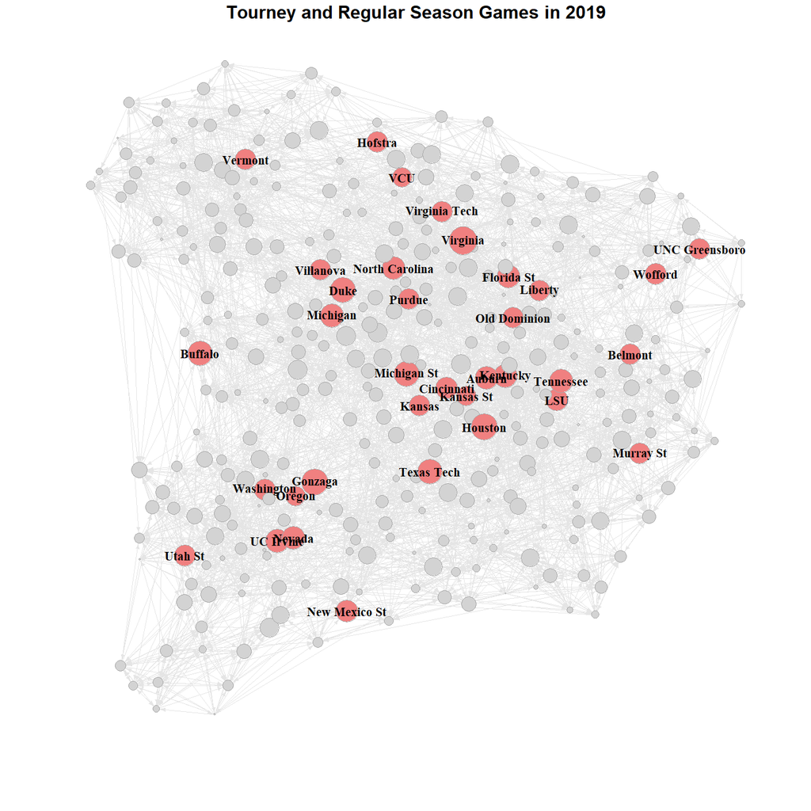

```r
vertex_fullnames <- as.character(vertex_ids$TeamName)
g_teams_full <- set_vertex_attr(g_teams_full, "fullname", value=vertex_fullnames)
# Plot the network
vertex_size <- as.numeric(strength(g_teams_full, mode="in"))*0.25
# Plot the graph
plot.igraph(g_teams_full, edge.arrow.size=0.5, layout=layout.fruchterman.reingold, edge.width=0.01,
            vertex.size=vertex_size, vertex.frame.color='darkgrey', edge.color='gray90',
            vertex.label=ifelse(vertex_size>6, vertex.attributes(g_teams_full)$fullname, NA),
            vertex.label.color='black', vertex.label.font=2, vertex.label.cex=1.4,
            vertex.color=ifelse(vertex_size>6, "lightcoral", "lightgray"))
title("Tourney and Regular Season Games in 2019",cex.main=2)
```

```r
# Combine regular season and tourney
df_FullDetailedResults <- rbind(df_RegularSeasonDetailedResults, df_TourneyDetailedResults) %>%
  filter(Season == 2019)
## calculate possessions per game statistic: field goal attempts + 0.475 x free throw attempts - offensive rebounds + turnovers
# regular season
season_stats <- df_FullDetailedResults %>%
  mutate(WPoss = WFGA + (WFTA * 0.475) + WTO - WOR,
         LPoss = LFGA + (LFTA * 0.475) + LTO - LOR)
#---------- tidy data for regular season totals ----------#
# First I will define a function that will take the detailed results data and reshape it so that it results in a dataframe where
# each observation is a team for that season and their totals statistics for that season. It will also calculate the statistics allowed
# for the season. This function only requires one parameter to be passed to it: either the regular season or Tourney detailed data.
# IMPORTANT: #
# The data required for this function to work is either the regular season or tourney detailed stats, and the "teams" dataset
reshape_detailed_results <- function(detailed_dataset) {

  season_team_stats_tot <- rbind(
    detailed_dataset %>%
      select(Season, DayNum, TeamID=WTeamID, Score=WScore, OScore=LScore, WLoc, NumOT, Poss=WPoss, FGM=WFGM, FGA=WFGA, FGM3=WFGM3,  FGA3=WFGA3, FTM=WFTM, FTA=WFTA, OR=WOR,
             DR=WDR, Ast=WAst, TO=WTO, Stl=WStl, Blk=WBlk, PF=WPF, OPoss=LPoss, OFGM=LFGM, OFGA=LFGA, OFGM3=LFGM3, OFGA3=LFGA3, OFTM=LFTM, OFTA=LFTA, O_OR=LOR, ODR=LDR,
             OAst=LAst, OTO=LTO, OStl=LStl, OBlk=LBlk, OPF=LPF) %>%
      mutate(Winner=1),

    detailed_dataset %>%
      select(Season, DayNum, TeamID=LTeamID, Score=LScore, OScore=WScore, WLoc, NumOT, Poss=LPoss, FGM=LFGM, FGA=LFGA, FGM3=LFGM3,  FGA3=LFGA3, FTM=LFTM, FTA=LFTA, OR=LOR,
             DR=LDR, Ast=LAst, TO=LTO, Stl=LStl, Blk=LBlk, PF=LPF, OPoss=WPoss, OFGM=WFGM, OFGA=WFGA, OFGM3=WFGM3, OFGA3=WFGA3, OFTM=WFTM, OFTA=WFTA, O_OR=WOR, ODR=WDR,
             OAst=WAst, OTO=WTO, OStl=WStl, OBlk=WBlk, OPF=WPF) %>%
      mutate(Winner=0)) %>%
    group_by(Season, TeamID) %>%
    summarise(GP = n(),
              wins = sum(Winner),
              TotPoints = sum(Score),
              TotPointsAllow = sum(OScore),
              NumOT = sum(NumOT),
              TotPos = sum(Poss),
              TotFGM = sum(FGM),
              TotFGA = sum(FGA),
              TotFGM3 = sum(FGM3),
              TotFGA3 = sum(FGA3),
              TotFTM = sum(FTM),
              TotFTA = sum(FTA),
              TotOR = sum(OR),
              TotDR = sum(DR),
              TotAst = sum(Ast),
              TotTO = sum(TO),
              TotStl = sum(Stl),
              TotBlk = sum(Blk),
              TotPF = sum(PF),
              TotPossAllow = sum(OPoss),
              TotFGMAllow = sum(OFGM),
              TotFGAAllow = sum(OFGA),
              TotFGM3Allow = sum(OFGM3),
              TotFGA3Allow = sum(OFGA3),
              TotFTMAllow = sum(OFTM),
              TotFTAAllow = sum(OFTA),
              TotORAllow = sum(O_OR),
              TotDRAllow = sum(ODR),
              TotAstAllow = sum(OAst),
              TotTOAllow = sum(OTO),
              TotStlAllow = sum(OStl),
              TotBlkAllow = sum(OBlk),
              TotPFAllow = sum(OPF))

}
## Store the results to a dataframe
season_team_stats_tot <- reshape_detailed_results(season_stats)
## calculate win percentage
season_team_stats_tot$WinPerc <- season_team_stats_tot$wins / season_team_stats_tot$GP
#---------- Create a dataframe of season averages for each team ----------#
# Next I will define a function that takes in the totals dataframe from the above function and calculate a season averages dataset.
# this function also only requires one parameter to be passed to it, the totals dataframe.
calculate_detailed_averages <- function(totals_dataframe) {

  averages <- totals_dataframe

  cols <- names(averages[,c(5:35)])

  for (eachcol in cols) {
    averages[,eachcol] <- round(averages[,eachcol] / averages$GP,2)

  }

  averages <- averages %>%
    rename(AvgPoints = TotPoints, AvgPointsAllow=TotPointsAllow, AvgOT=NumOT, AvgPoss=TotPos, AvgFGM=TotFGM,  AvgFGA=TotFGA, AvgFGM3=TotFGM3, AvgFGA3=TotFGA3, AvgFTM=TotFTM,
           AvgFTA=TotFTA, AvgOR=TotOR, Avg_DR=TotDR, AvgAst=TotAst, AvgTO=TotTO, AvgStl=TotStl, Avg_Blk=TotBlk, AvgPF=TotPF, AvgPossAllow=TotPossAllow, AvgFGMAllow=TotFGMAllow,
           AvgFGAAllow=TotFGAAllow,  AvgFGM3Allow=TotFGM3Allow, AvgFGA3Allow=TotFGA3Allow,  AvgFTMAllow=TotFTMAllow, AvgFTAAllow=TotFTAAllow,
           AvgORAllow=TotORAllow, AvgDRAllow=TotDRAllow,  AvgAstAllow=TotAstAllow, AvgTOAllow=TotTOAllow, AvgStlAllow=TotStlAllow,  AvgBlkAllow=TotBlkAllow,
           AvgPFAllow=TotPFAllow) %>%
    mutate(PointsPerPoss = AvgPoints / AvgPoss,
           PointsPerPossAllow = AvgPointsAllow / AvgPossAllow)

  return(averages)

}
# create an averages dataframe
season_team_stats_averages <- calculate_detailed_averages(season_team_stats_tot)
#---------- Create a dataframe of advanved stats for each team ----------#
# Create advanved stats dataframe
advanced_stats_season <- season_team_stats_tot %>%
  mutate(WinPerc = wins / GP,
         OffRtg = 100 * (TotPoints / TotPos),
         DefRtg = 100 * (TotPointsAllow / TotPossAllow),
         SoS = OffRtg - DefRtg,
         Pie = TotPoints + TotFGM + TotFTM - TotFGA - TotFTA + TotDR + (0.5 * TotOR) + TotAst + TotStl + (0.5 * TotBlk) - TotPF - TotTO,
         OPie = TotPointsAllow + TotFGMAllow + TotFTMAllow - TotFGAAllow - TotFTAAllow + TotDRAllow + (0.5 * TotORAllow) + TotAstAllow + TotStlAllow + (0.5 * TotBlkAllow) - TotPFAllow - TotTOAllow,
         Tie = Pie / (Pie + OPie) * 100,
         AstRatio = 100 * TotAst / (TotFGA + (0.475 * TotFTA) + TotAst + TotTO),
         TORatio = 100 * TotTO / (TotFGA + (0.475 * TotFTA) + TotAst + TotTO),
         TSPerc = 100 * TotPoints / (2 * (TotFGA + (0.475 * TotFTA))),
         FTRate = TotFTA / TotFGA,
         ThreesShare = TotFGA3 / TotFGA,
         OffRebPerc = TotOR / (TotOR + TotDRAllow),
         DefRebPerc = TotDR / (TotDR + TotORAllow),
         TotRebPerc = (TotDR + TotOR) / (TotDR + TotOR + TotDRAllow + TotORAllow)) %>%
  select(Season, TeamID, TotPoints, TotPointsAllow, wins, WinPerc, OffRtg, DefRtg, SoS, Pie, OPie, Tie, AstRatio, TORatio, TSPerc, FTRate, ThreesShare, OffRebPerc, DefRebPerc, TotRebPerc)
### Combine average and advanced statistics
team_stats_full <- season_team_stats_averages %>% left_join(advanced_stats_season)
```

OffRtg - Offensive Rating DefRtg - Deffensive Rating OffRebPerc - Offensive Rebounding DefRebPerc - Defensive Rebounding TotRebPerc - Total Rebounding AvgFGA3 - Average Threes Attempted AvgFGM3 - Average Threes Made AvgOR - Average Offensive Rebounds Avg_DR - Average Defensive Rebounds Avg_Blk - Average Blocks AvgStl - Average Steals

TSPerc - True Shooting Percentage AstRatio - Assist Ratio TORatio - Turnover Ratio AvgPoss - Average Possessions FTRate - Free Throw Rate ThreesShare - Three Pointers Share

```r
g_teams_full_net
```

```
 Network attributes:
  vertices = 353
  directed = TRUE
  hyper = FALSE
  loops = FALSE
  multiple = FALSE
  bipartite = FALSE
  total edges= 4518
    missing edges= 0
    non-missing edges= 4518

 Vertex attribute names:
    AstRatio AvgPoss conf_name EFGPerc FTRate fullname ThreesShare TORatio TSPerc vertex.names

 Edge attribute names not shown
```

```r
ergm_model <- ergm(g_teams_full_net ~ edges + mutual +
                        nodeicov("TSPerc") +
                        nodeicov("AstRatio") +
                        nodeicov("TORatio") +
                        nodeicov("ThreesShare") +
                        nodeicov("FTRate") +
                        nodeicov("AvgPoss") +

                        diff("TSPerc") +
                        diff("AstRatio") +
                        diff("TORatio") +
                        diff("ThreesShare") +
                        diff("FTRate") +
                        diff("AvgPoss"),
                   burnin=20000,
                   MCMCsamplesize=70000,
                   verbose=T)
```

[output not shown]

[output cut: 15 more lines]

[output not shown]